# NOAA Storm Database Analysis

#### Events affecting Economy and causing fatalities or injuries

## Synopsis

Storms and other severe weather events can cause both public health and economic problems for communities and municipalities. Many severe events can result in fatalities, injuries, and property damage, and preventing such outcomes to the extent possible is a key concern.

This project analyzes the U.S. National Oceanic and Atmospheric Administration’s (NOAA) storm database to determine the events affecting the most the economy or causing the most fatalities or injuries.

## Data Processing

#### Loading required libraries

```r
library(dplyr, quietly = TRUE)
library(R.utils, quietly = TRUE)
```

#### Downloading the data

```r
fileUrl <- "https://d396qusza40orc.cloudfront.net/repdata%2Fdata%2FStormData.csv.bz2"

if (!file.exists("data")) {
  dir.create("data")
}

if (!file.exists("./data/repdata-data-StormData.csv")) {
  if (!file.exists("./data/repdata-data-StormData.csv.bz2")) {
    download.file(fileUrl, destfile = "./data/repdata-data-StormData.csv.bz2")
  }
  bunzip2("./data/repdata-data-StormData.csv.bz2", "./data/repdata-data-StormData.csv")
}

noaa_full <- read.csv("./data/repdata-data-StormData.csv")
```

#### Subsetting and cleaning the data

We keep only the fields pertinent to our analysis:

- EVTYPE: the type of event
- FATALITIES: number of fatalities
- INJURIES: number of injuries
- PROPDMG: damage to properties in USD
- PROPDMGEXP: magnitude for properties damage (K for thousands, M for millions, B for billions)
- CROPDMG: damage to crops in USD
- CROPDMGEXP: magnitude for crops damage (K for thousands, M for millions, B for billions)

```r
noaa <- noaa_full %>% select(EVTYPE, FATALITIES, INJURIES, PROPDMG, PROPDMGEXP, CROPDMG, CROPDMGEXP)
```

As the magnitude for damages amount contains invalid characters and is not practical in this format for the rest of the analysis, we clean the data and convert it to a numeric value we can multiply with the damage amount to get the final damage value in USD. We consider the invalid characters to be missing data having no value.

The valid values are K for thousands, M for millions and B for billions (as specified in the National Weather Service Storm Data Documentation)

```r
noaa$PROPDMGEXP <- sub("[-?+H123456789]", "0", noaa$PROPDMGEXP, ignore.case = TRUE)
noaa$PROPDMGEXP <- sub("^$", "0", noaa$PROPDMGEXP)
noaa$PROPDMGEXP <- sub("^K$", "1000", noaa$PROPDMGEXP, ignore.case = TRUE)
noaa$PROPDMGEXP <- sub("^M$", "1000000", noaa$PROPDMGEXP, ignore.case = TRUE)
noaa$PROPDMGEXP <- sub("^B$", "1000000000", noaa$PROPDMGEXP, ignore.case = TRUE)
noaa$PROPDMGEXP <- as.numeric(noaa$PROPDMGEXP)


noaa$CROPDMGEXP <- sub("[-?+H123456789]", "0", noaa$CROPDMGEXP, ignore.case = TRUE)
noaa$CROPDMGEXP <- sub("^$", "0", noaa$CROPDMGEXP)
noaa$CROPDMGEXP <- sub("^K$", "1000", noaa$CROPDMGEXP, ignore.case = TRUE)
noaa$CROPDMGEXP <- sub("^M$", "1000000", noaa$CROPDMGEXP, ignore.case = TRUE)
noaa$CROPDMGEXP <- sub("^B$", "1000000000", noaa$CROPDMGEXP, ignore.case = TRUE)
noaa$CROPDMGEXP <- as.numeric(noaa$CROPDMGEXP)
```

## Results

#### Types of events the most harmful with respect to population health since 1950 across USA

From the NOAA data, the number of injuries and fatalities are helpful to determine the impact of an event on the population health across USA since 1950.

We group the data per event type and sum the number of injuries and fatalities per event type, plotting the top 10 events causing the most injuries and fatalities.

##### Top 10 Events causing the most fatalities

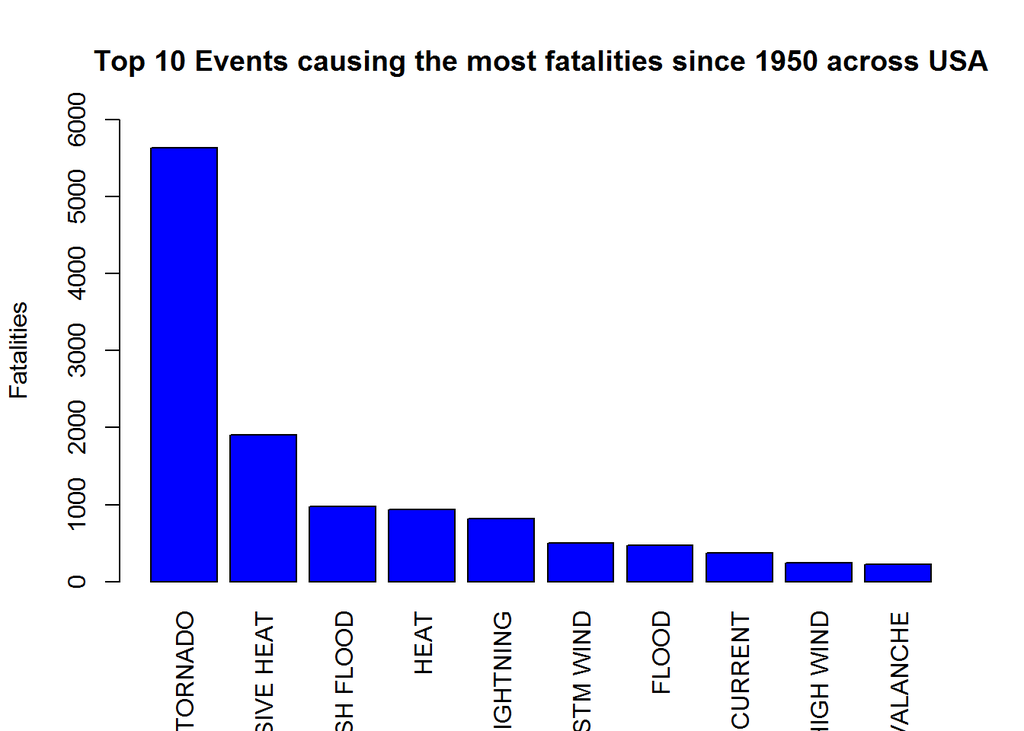

```r
event_fatalities <- noaa %>%
                      filter(FATALITIES > 0) %>%
                      group_by(EVTYPE) %>%
                      summarise( FATALITIES = sum(FATALITIES, na.rm = TRUE)) %>%
                      arrange(desc(FATALITIES)) %>%
                      head(10)


barplot(event_fatalities$FATALITIES, names.arg=event_fatalities$EVTYPE,
        ylab="Fatalities",
        las=3,
        col = "blue",
        ylim=c(0,6000),
        main="Top 10 Events causing the most fatalities since 1950 across USA")
```

##### Top 10 Events causing the most injuries

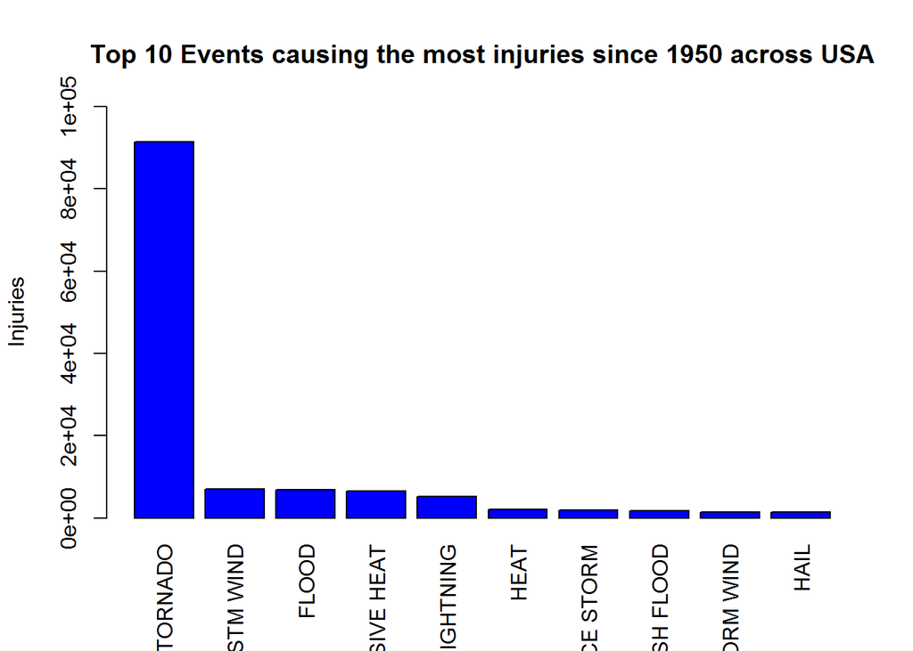

```r
event_injuries <- noaa %>%
                    filter(INJURIES > 0) %>%
                    group_by(EVTYPE) %>%
                    summarise( INJURIES = sum(INJURIES, na.rm = TRUE)) %>%
                    arrange(desc(INJURIES)) %>%
                    head(10)

barplot(event_injuries$INJURIES, names.arg=event_injuries$EVTYPE,
        ylab="Injuries",
        las=3,
        col = "blue",
        ylim=c(0,100000),
        main="Top 10 Events causing the most injuries since 1950 across USA")
```

#### Types of events with the greatest economic consequences since 1950 across USA

We can extract from the NOAA data two economic consequences across USA since 1950 to events: damages to properties and damages to crop.

We group the data per event type and sum the damages to crop and properties, plotting the top 10 events causing the greatest economic consequences.

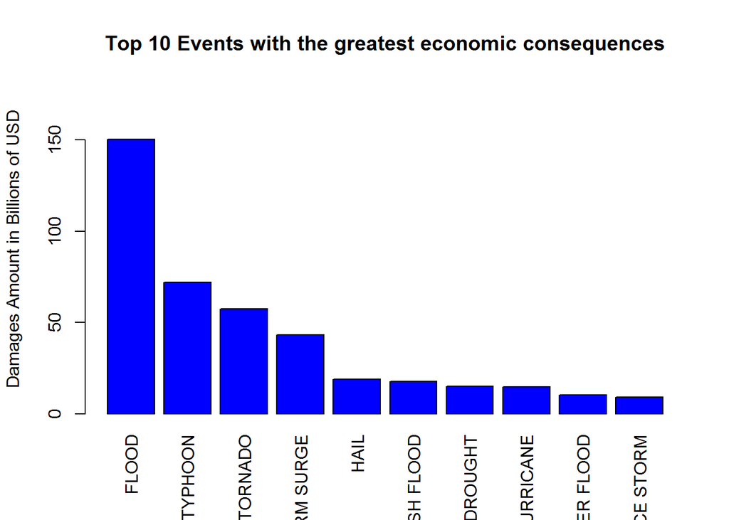

```r
event_economic <- noaa %>%
                    mutate(PROPCROPDMG = ((PROPDMG * PROPDMGEXP) + (CROPDMG * CROPDMGEXP)) ) %>%
                    group_by(EVTYPE) %>%
                    summarise( DAMAGE = sum(PROPCROPDMG, na.rm = TRUE)) %>%
                    arrange(desc(DAMAGE)) %>%
                    head(10)

barplot((event_economic$DAMAGE / 1000000000), names.arg=event_economic$EVTYPE,
        ylab="Damages Amount in Billions of USD",
        las=3,
        col = "blue",
        ylim=c(0,180),
        main="Top 10 Events with the greatest economic consequences")
```